# homework_5

# Q.8.1

Prediction of Covid-19 cases given confirmed,active ,deceased, recovered ,and positive cases in a specific geographical region is of an interest. A comparison of linear and multi-linear regression model is of an interest where R2 score would be close to 1 indicating a strong prediction model to forecase the next coming days active cases. The correlation would be among the dependent variable(active cases) and independent variables(positive, deceased, and recovered).

# Q.8.2

#cleaning the environment

```r
rm(list=ls())
```

#setting up the working directory

#bringing in the required/possible packages to be used

#importing the data

```r
cdata <- read.table('uscrime.txt', stringsAsFactors = FALSE, header = TRUE)
```

#set seed for random number generation to allow for replication of the data

```r
set.seed(1)
```

#Exploratory analysis of the data

```r
head(cdata)
```

```
##      M So   Ed  Po1  Po2    LF   M.F Pop   NW    U1  U2 Wealth Ineq     Prob
## 1 15.1  1  9.1  5.8  5.6 0.510  95.0  33 30.1 0.108 4.1   3940 26.1 0.084602
## 2 14.3  0 11.3 10.3  9.5 0.583 101.2  13 10.2 0.096 3.6   5570 19.4 0.029599
## 3 14.2  1  8.9  4.5  4.4 0.533  96.9  18 21.9 0.094 3.3   3180 25.0 0.083401
## 4 13.6  0 12.1 14.9 14.1 0.577  99.4 157  8.0 0.102 3.9   6730 16.7 0.015801
## 5 14.1  0 12.1 10.9 10.1 0.591  98.5  18  3.0 0.091 2.0   5780 17.4 0.041399
## 6 12.1  0 11.0 11.8 11.5 0.547  96.4  25  4.4 0.084 2.9   6890 12.6 0.034201
##      Time Crime
## 1 26.2011   791
## 2 25.2999  1635
## 3 24.3006   578
## 4 29.9012  1969
## 5 21.2998  1234
## 6 20.9995   682
```

#range of the crime data column

```r
range(cdata$Crime)
```

```
## [1]  342 1993
```

#summary of the dataset

```r
summary(cdata)
```

```
##        M               So               Ed             Po1
##  Min.   :11.90   Min.   :0.0000   Min.   : 8.70   Min.   : 4.50
##  1st Qu.:13.00   1st Qu.:0.0000   1st Qu.: 9.75   1st Qu.: 6.25
##  Median :13.60   Median :0.0000   Median :10.80   Median : 7.80
##  Mean   :13.86   Mean   :0.3404   Mean   :10.56   Mean   : 8.50
##  3rd Qu.:14.60   3rd Qu.:1.0000   3rd Qu.:11.45   3rd Qu.:10.45
##  Max.   :17.70   Max.   :1.0000   Max.   :12.20   Max.   :16.60
##       Po2               LF              M.F              Pop
##  Min.   : 4.100   Min.   :0.4800   Min.   : 93.40   Min.   :  3.00
##  1st Qu.: 5.850   1st Qu.:0.5305   1st Qu.: 96.45   1st Qu.: 10.00
##  Median : 7.300   Median :0.5600   Median : 97.70   Median : 25.00
##  Mean   : 8.023   Mean   :0.5612   Mean   : 98.30   Mean   : 36.62
##  3rd Qu.: 9.700   3rd Qu.:0.5930   3rd Qu.: 99.20   3rd Qu.: 41.50
##  Max.   :15.700   Max.   :0.6410   Max.   :107.10   Max.   :168.00
##        NW              U1                U2            Wealth
##  Min.   : 0.20   Min.   :0.07000   Min.   :2.000   Min.   :2880
##  1st Qu.: 2.40   1st Qu.:0.08050   1st Qu.:2.750   1st Qu.:4595
##  Median : 7.60   Median :0.09200   Median :3.400   Median :5370
##  Mean   :10.11   Mean   :0.09547   Mean   :3.398   Mean   :5254
##  3rd Qu.:13.25   3rd Qu.:0.10400   3rd Qu.:3.850   3rd Qu.:5915
##  Max.   :42.30   Max.   :0.14200   Max.   :5.800   Max.   :6890
##       Ineq            Prob              Time           Crime
##  Min.   :12.60   Min.   :0.00690   Min.   :12.20   Min.   : 342.0
##  1st Qu.:16.55   1st Qu.:0.03270   1st Qu.:21.60   1st Qu.: 658.5
##  Median :17.60   Median :0.04210   Median :25.80   Median : 831.0
##  Mean   :19.40   Mean   :0.04709   Mean   :26.60   Mean   : 905.1
##  3rd Qu.:22.75   3rd Qu.:0.05445   3rd Qu.:30.45   3rd Qu.:1057.5
##  Max.   :27.60   Max.   :0.11980   Max.   :44.00   Max.   :1993.0
```

#Statistical Summary of the dataset

```r
basicStats(cdata, ci=.95)
```

```
##                      M        So         Ed        Po1        Po2        LF
## nobs         47.000000 47.000000  47.000000  47.000000  47.000000 47.000000
## NAs           0.000000  0.000000   0.000000   0.000000   0.000000  0.000000
## Minimum      11.900000  0.000000   8.700000   4.500000   4.100000  0.480000
## Maximum      17.700000  1.000000  12.200000  16.600000  15.700000  0.641000
## 1. Quartile  13.000000  0.000000   9.750000   6.250000   5.850000  0.530500
## 3. Quartile  14.600000  1.000000  11.450000  10.450000   9.700000  0.593000
## Mean         13.857447  0.340426  10.563830   8.500000   8.023404  0.561191
## Median       13.600000  0.000000  10.800000   7.800000   7.300000  0.560000
## Sum         651.300000 16.000000 496.500000 399.500000 377.100000 26.376000
## SE Mean       0.183318  0.069866   0.163179   0.433496   0.407858  0.005895
## LCL Mean     13.488447  0.199793  10.235367   7.627418   7.202429  0.549326
## UCL Mean     14.226446  0.481058  10.892292   9.372582   8.844379  0.573057
## Variance      1.579454  0.229417   1.251489   8.832174   7.818353  0.001633
## Stdev         1.256763  0.478975   1.118700   2.971897   2.796132  0.040412
## Skewness      0.821917  0.652139  -0.318987   0.890124   0.844367  0.270675
## Kurtosis      0.377753 -1.607569  -1.149253   0.162309   0.008590 -0.888732
##                     M.F         Pop         NW        U1         U2
## nobs          47.000000   47.000000  47.000000 47.000000  47.000000
## NAs            0.000000    0.000000   0.000000  0.000000   0.000000
## Minimum       93.400000    3.000000   0.200000  0.070000   2.000000
## Maximum      107.100000  168.000000  42.300000  0.142000   5.800000
## 1. Quartile   96.450000   10.000000   2.400000  0.080500   2.750000
## 3. Quartile   99.200000   41.500000  13.250000  0.104000   3.850000
## Mean          98.302128   36.617021  10.112766  0.095468   3.397872
## Median        97.700000   25.000000   7.600000  0.092000   3.400000
## Sum         4620.200000 1721.000000 475.300000  4.487000 159.700000
## SE Mean        0.429826    5.553254   1.499912  0.002630   0.123190
## LCL Mean      97.436933   25.438902   7.093599  0.090175   3.149905
## UCL Mean      99.167322   47.795141  13.131933  0.100762   3.645840
## Variance       8.683256 1449.415356 105.737660  0.000325   0.713256
## Stdev          2.946737   38.071188  10.282882  0.018029   0.844545
## Skewness       0.993223    1.854230   1.379966  0.774876   0.542264
## Kurtosis       0.652010    3.078936   1.077648 -0.131208   0.173008
##                    Wealth       Ineq      Prob        Time        Crime
## nobs            47.000000  47.000000 47.000000   47.000000 4.700000e+01
## NAs              0.000000   0.000000  0.000000    0.000000 0.000000e+00
## Minimum       2880.000000  12.600000  0.006900   12.199600 3.420000e+02
## Maximum       6890.000000  27.600000  0.119804   44.000400 1.993000e+03
## 1. Quartile   4595.000000  16.550000  0.032701   21.600350 6.585000e+02
## 3. Quartile   5915.000000  22.750000  0.054450   30.450750 1.057500e+03
## Mean          5253.829787  19.400000  0.047091   26.597921 9.050851e+02
## Median        5370.000000  17.600000  0.042100   25.800600 8.310000e+02
## Sum         246930.000000 911.800000  2.213295 1250.102300 4.253900e+04
## SE Mean        140.746508   0.581944  0.003317    1.033730 5.641514e+01
## LCL Mean      4970.521762  18.228608  0.040416   24.517131 7.915273e+02
## UCL Mean      5537.137813  20.571392  0.053767   28.678712 1.018643e+03
## Variance    931050.231267  15.916957  0.000517   50.224083 1.495854e+05
## Stdev          964.909442   3.989606  0.022737    7.086895 3.867627e+02
## Skewness        -0.381952   0.367063  0.883336    0.371275 1.053927e+00
## Kurtosis        -0.613169  -1.138824  0.749579   -0.413474 7.776280e-01
```

#Plotting density of each column of the data

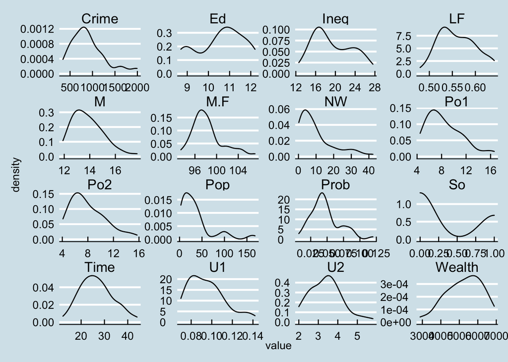

```r
density <- cdata %>%
  gather() %>%
  ggplot(aes(value)) +
  facet_wrap(~ key, scales = "free") +
  geom_density()+theme_economist()+scale_colour_economist()
density
```

#It seems from the plot above that, except for `time` no other predictor/feature has a normal distribution. Continuing with the analysis with a better understanding of the dataset.

# the given test dataset to predict the crime for

#calling this testdata throughout the analysis

```r
testdata<-data.frame(M = 14.0,
                     So = 0,
                     Ed = 10.0,
                     Po1 = 12.0,
                     Po2 = 15.5,
                     LF = 0.640,
                     M.F = 94.0,
                     Pop = 150,
                     NW = 1.1,
                     U1 = 0.120,
                     U2 = 3.6,
                     Wealth = 3200,
                     Ineq = 20.1,
                     Prob = 0.04,
                     Time = 39.0)

testdata
```

```
##    M So Ed Po1  Po2   LF M.F Pop  NW   U1  U2 Wealth Ineq Prob Time
## 1 14  0 10  12 15.5 0.64  94 150 1.1 0.12 3.6   3200 20.1 0.04   39
```

# Building the base model(model_1)

#For the base model, all predictors/features are used.

```r
model_1 <- lm(Crime ~. ,data = cdata)
summary(model_1)
```

```
##
## Call:
## lm(formula = Crime ~ ., data = cdata)
##
## Residuals:
##     Min      1Q  Median      3Q     Max
## -395.74  -98.09   -6.69  112.99  512.67
##
## Coefficients:
##               Estimate Std. Error t value Pr(>|t|)
## (Intercept) -5.984e+03  1.628e+03  -3.675 0.000893 ***
## M            8.783e+01  4.171e+01   2.106 0.043443 *
## So          -3.803e+00  1.488e+02  -0.026 0.979765
## Ed           1.883e+02  6.209e+01   3.033 0.004861 **
## Po1          1.928e+02  1.061e+02   1.817 0.078892 .
## Po2         -1.094e+02  1.175e+02  -0.931 0.358830
## LF          -6.638e+02  1.470e+03  -0.452 0.654654
## M.F          1.741e+01  2.035e+01   0.855 0.398995
## Pop         -7.330e-01  1.290e+00  -0.568 0.573845
## NW           4.204e+00  6.481e+00   0.649 0.521279
## U1          -5.827e+03  4.210e+03  -1.384 0.176238
## U2           1.678e+02  8.234e+01   2.038 0.050161 .
## Wealth       9.617e-02  1.037e-01   0.928 0.360754
## Ineq         7.067e+01  2.272e+01   3.111 0.003983 **
## Prob        -4.855e+03  2.272e+03  -2.137 0.040627 *
## Time        -3.479e+00  7.165e+00  -0.486 0.630708
## ---
## Signif. codes:  0 '***' 0.001 '**' 0.01 '*' 0.05 '.' 0.1 ' ' 1
##
## Residual standard error: 209.1 on 31 degrees of freedom
## Multiple R-squared:  0.8031, Adjusted R-squared:  0.7078
## F-statistic: 8.429 on 15 and 31 DF,  p-value: 3.539e-07
```

Linear Regression or Linear Model(LM) is used to predict outcome variable(y)-Crime in our dataset- on the basis of one/multiple predictor variables(x). The overall quality of the linear regression fit can be assessed using RSE, R2, and F-statistic. In the above model we see the RSE is 209, R2 is 0.7, and F-statistic is 8.4.

RSE or model sigma, corresponds to the prediction error. The lower the RSE the best the model fits to our data. R2 ranges from 0 to 1 and represents the proportion of variation in the outcome variable. The closer it is to 1, the larger proportion of the variability in the outcome. R2 in our model is pretty good. F-statistics that gives the overall significance of the model. 8.4 producing p.value of 3.539e-07 p<0.05 shows statistical high significance.

#model_1 coefficients:

```r
summary(model_1)$coef
```

```
##                  Estimate   Std. Error     t value     Pr(>|t|)
## (Intercept) -5.984288e+03 1628.3183733 -3.67513362 0.0008929887
## M            8.783017e+01   41.7138664  2.10553902 0.0434433942
## So          -3.803450e+00  148.7551399 -0.02556853 0.9797653725
## Ed           1.883243e+02   62.0883761  3.03316541 0.0048614327
## Po1          1.928043e+02  106.1096757  1.81702882 0.0788919769
## Po2         -1.094219e+02  117.4775356 -0.93142851 0.3588295738
## LF          -6.638261e+02 1469.7288208 -0.45166573 0.6546540941
## M.F          1.740686e+01   20.3538427  0.85521225 0.3989953316
## Pop         -7.330081e-01    1.2895554 -0.56841928 0.5738452309
## NW           4.204461e+00    6.4808922  0.64874725 0.5212791189
## U1          -5.827103e+03 4210.2890365 -1.38401489 0.1762380311
## U2           1.677997e+02   82.3359552  2.03798780 0.0501612829
## Wealth       9.616624e-02    0.1036661  0.92765416 0.3607537824
## Ineq         7.067210e+01   22.7165213  3.11104410 0.0039831365
## Prob        -4.855266e+03 2272.3746212 -2.13664850 0.0406269260
## Time        -3.479018e+00    7.1652752 -0.48553862 0.6307084351
```

#Root Mean Square Error (RMSE) measures the model prediction error.(the avg difference of the obsesereved values of the outcome and the predicted values by the model)

```r
print(sprintf("RMSE for Model_1 = %0.2f", sigma(model_1) ))
```

```
## [1] "RMSE for Model_1 = 209.06"
```

#predicting crime rate for the given test data

```r
predict(model_1, testdata)
```

```
##        1
## 155.4349
```

Here we are predicting an outcome variable (y)-Crime- on the basis of multiple distinct predictor variables(x).Therefore, this is a multiple linear regression. The predicted value of 155.43 is way below the minimum of crime rate within our dataset. Although the model seemed to be good, the prediction is not. This might be due to overfitting or the fact that all predictors were count for.

Note: when building a regression model, we need to asses the preformance of the predictive mode (e.g.model_1) and evaluate how well the model is in predicting the outcome of a new test data(e.g.testdata).

#percentage of error for model_1 (23%)

```r
sigma(model_1)*100/mean(cdata$Crime)
```

```
## [1] 23.09887
```

# Building a second model(model_2) with fewer predictors

#let’s look at how graphically these variables are correlated

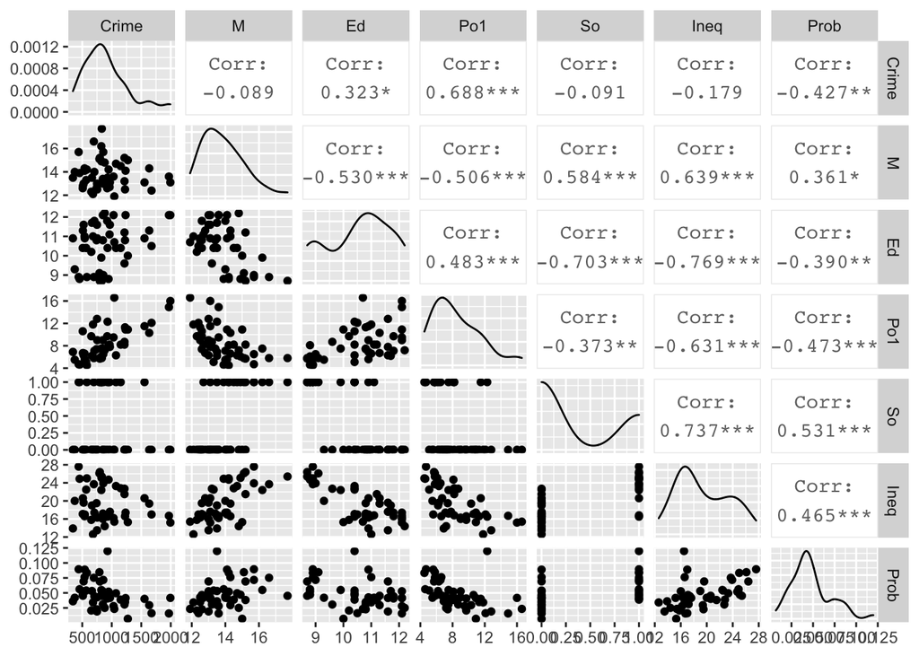

```r
ggpairs(cdata, columns = c("Crime","M", "Ed", "Po1", "So","Ineq","Prob"))
```

#Using summary output as a guide for model_1, took predictors with ., * & ** only, and fed that to the lm function again; creating the second model:

```r
model_2<-lm(Crime ~  M + Ed + Po1 + U2 + Ineq + Prob,data=cdata,x=TRUE,y=TRUE)
summary(model_2)
```

```
##
## Call:
## lm(formula = Crime ~ M + Ed + Po1 + U2 + Ineq + Prob, data = cdata,
##     x = TRUE, y = TRUE)
##
## Residuals:
##     Min      1Q  Median      3Q     Max
## -470.68  -78.41  -19.68  133.12  556.23
##
## Coefficients:
##             Estimate Std. Error t value Pr(>|t|)
## (Intercept) -5040.50     899.84  -5.602 1.72e-06 ***
## M             105.02      33.30   3.154  0.00305 **
## Ed            196.47      44.75   4.390 8.07e-05 ***
## Po1           115.02      13.75   8.363 2.56e-10 ***
## U2             89.37      40.91   2.185  0.03483 *
## Ineq           67.65      13.94   4.855 1.88e-05 ***
## Prob        -3801.84    1528.10  -2.488  0.01711 *
## ---
## Signif. codes:  0 '***' 0.001 '**' 0.01 '*' 0.05 '.' 0.1 ' ' 1
##
## Residual standard error: 200.7 on 40 degrees of freedom
## Multiple R-squared:  0.7659, Adjusted R-squared:  0.7307
## F-statistic: 21.81 on 6 and 40 DF,  p-value: 3.418e-11
```

#model_2 coefficients

```r
summary(model_2)$coef
```

```
##                Estimate Std. Error   t value     Pr(>|t|)
## (Intercept) -5040.50498  899.84338 -5.601536 1.715273e-06
## M             105.01957   33.29925  3.153812 3.054440e-03
## Ed            196.47120   44.75437  4.389989 8.072016e-05
## Po1           115.02419   13.75359  8.363213 2.561505e-10
## U2             89.36604   40.90567  2.184686 3.483130e-02
## Ineq           67.65322   13.93575  4.854653 1.879377e-05
## Prob        -3801.83628 1528.09733 -2.487954 1.711387e-02
```

#test on the test data

```r
predict(model_2,testdata)
```

```
##        1
## 1304.245
```

Comparing to the predicted value of a crime we got from model_1, this one is a much better prediction and within the range of our data. However, how much better is it? some calculations below shows that RMSE only improved a bit from 209 to 200, and percentage of error is 22% down by only 1% from 23% calculated for model_1.

Also, the R2, and F-stat still look good with the significant predictors. Overall we are now more confidence that the second model is better than the first one. By how much? would require further investigation, maybe ANOVA test? Which will not get into, but would like to use the AIC/BIC to confirm my results.

#percentage of prediction error for model 2

```r
sigma(model_2)*100/mean(cdata$Crime)
```

```
## [1] 22.17359
```

```r
print(sprintf("RMSE for Model_2 = %0.2f", sigma(model_2) ))
```

```
## [1] "RMSE for Model_2 = 200.69"
```

#based on the lecture material, we can compare our models with AIC, and BIC - lower value demonstrates a better model.

```r
AIC(model_1,model_2)
```

```
##         df      AIC
## model_1 17 650.0291
## model_2  8 640.1661
```

```r
BIC(model_1,model_2)
```

```
##         df      BIC
## model_1 17 681.4816
## model_2  8 654.9673
```

Model_2 is slightly a better model, it seems our first model is over fitted and focusing on significant predictors improved our model and the RMSE moderately.